# INT303 Big Data Analytics

## The Interest in Science Problem from lecture slides

Dataframe construction:

```python
science = {
    'interest': ['Excited', 'Kind of interested', 'OK', 'Not great', 'Bored'],
    'before': [19, 25, 40, 5, 11],
    'after': [38, 30, 14, 6, 12]
}
dfscience = pd.DataFrame.from_dict(science).set_index("interest")[['before', 'after']]
dfscience
```

| interest | before | after |
| --- | --- | --- |
| Excited | 19 | 38 |
| Kind of interested | 25 | 30 |
| OK | 40 | 14 |
| Not great | 5 | 6 |
| Bored | 11 | 12 |

### Multiple Pie Charts

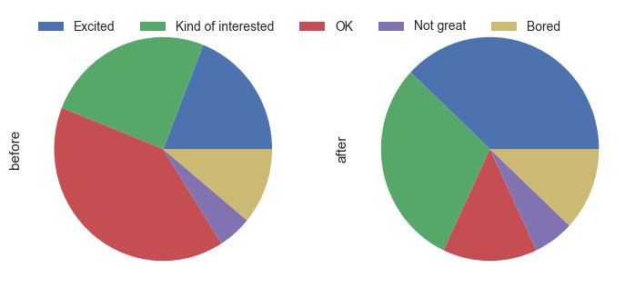

```python
fig, axs = plt.subplots(1,2, figsize = (8.5,4))
dfscience.before.plot(kind="pie", ax=axs[0], labels=None);
axs[0].legend(loc="upper left", ncol=5, labels=dfscience.index)
dfscience.after.plot(kind="pie", ax=axs[1], labels=None);
```

### Before and after bar charts

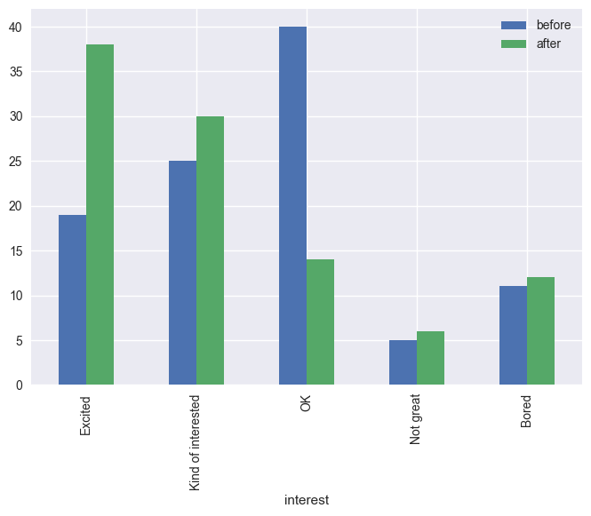

```python
dfscience.plot(kind="bar");
```

### Stacked Charts

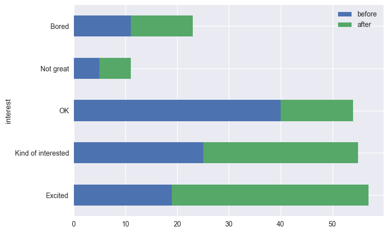

```python
dfscience.plot(kind="barh", stacked=True);
```

This is hard to read. We wznt to compare before and after easily. Sometimes the solution is a transpose!!

```python
dfscience.transpose()
```

| interest | Excited | Kind of interested | OK | Not great | Bored |
| --- | --- | --- | --- | --- | --- |
| before | 19 | 25 | 40 | 5 | 11 |
| after | 38 | 30 | 14 | 6 | 12 |

We have to play some games to get the ordering right...

```python
dfst = dfscience.transpose()
dfst.iloc[[1, 0],:]
```

| interest | Excited | Kind of interested | OK | Not great | Bored |
| --- | --- | --- | --- | --- | --- |
| after | 38 | 30 | 14 | 6 | 12 |
| before | 19 | 25 | 40 | 5 | 11 |

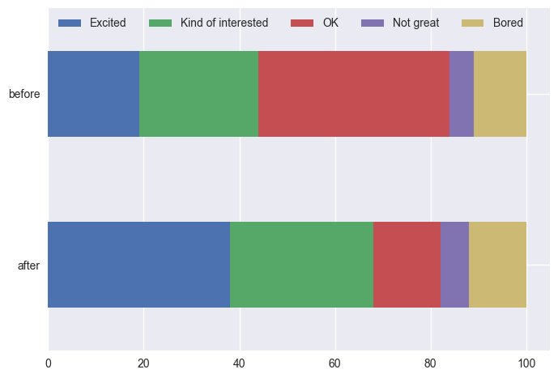

```python
dfscience.transpose().loc[['after', 'before'], :].plot(kind="barh", stacked=True)
plt.legend(loc=2, ncol=5);
```

Now we see that the blue and greens have it. Try and improve this plot. It still has too much chartjunk.

### Difference Bar chart

Sometimes a small data transformation makes the effect blindingly obvious. Here we just make a bar chart of the change!

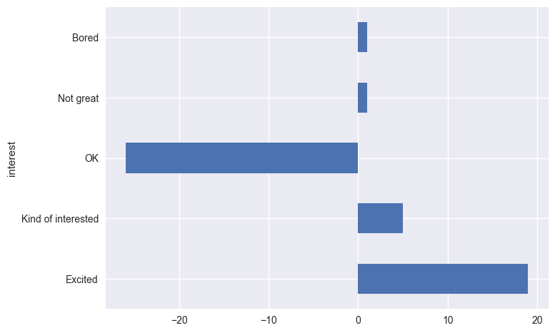

```python
(dfscience.after - dfscience.before).plot(kind="barh");
```

## Bacteria Dataset

For those want to play...

```python
antibiotics = [
  { "bacteria": "Mycobacterium tuberculosis", "penicillin": 800, "streptomycin": 5, "neomycin": 2, "gram": "negative" },
  { "bacteria": "Salmonella schottmuelleri", "penicillin": 10, "streptomycin": 0.8, "neomycin": 0.09, "gram": "negative" },
  { "bacteria": "Proteus vulgaris", "penicillin": 3, "streptomycin": 0.1, "neomycin": 0.1, "gram": "negative" },
  { "bacteria": "Klebsiella pneumoniae", "penicillin": 850, "streptomycin": 1.2, "neomycin": 1, "gram": "negative" },
  { "bacteria": "Brucella abortus", "penicillin": 1, "streptomycin": 2, "neomycin": 0.02, "gram": "negative" },
  { "bacteria": "Pseudomonas aeruginosa", "penicillin": 850, "streptomycin": 2, "neomycin": 0.4, "gram": "negative" },
  { "bacteria": "Escherichia coli", "penicillin": 100, "streptomycin": 0.4, "neomycin": 0.1, "gram": "negative" },
  { "bacteria": "Salmonella (Eberthella) typhosa", "penicillin": 1, "streptomycin": 0.4, "neomycin": 0.008, "gram": "negative" },
  { "bacteria": "Aerobacter aerogenes", "penicillin": 870, "streptomycin": 1, "neomycin": 1.6, "gram": "negative" },
  { "bacteria": "Brucella antracis", "penicillin": 0.001, "streptomycin": 0.01, "neomycin": 0.007, "gram": "positive" },
  { "bacteria": "Streptococcus fecalis", "penicillin": 1, "streptomycin": 1, "neomycin": 0.1, "gram": "positive" },
  { "bacteria": "Staphylococcus aureus", "penicillin": 0.03, "streptomycin": 0.03, "neomycin": 0.001, "gram": "positive" },
  { "bacteria": "Staphylococcus albus", "penicillin": 0.007, "streptomycin": 0.1, "neomycin": 0.001, "gram": "positive" },
  { "bacteria": "Streptococcus hemolyticus", "penicillin": 0.001, "streptomycin": 14, "neomycin": 10, "gram": "positive" },
  { "bacteria": "Streptococcus viridans", "penicillin": 0.005, "streptomycin": 10, "neomycin": 40, "gram": "positive" },
  { "bacteria": "Diplococcus pneumoniae", "penicillin": 0.005, "streptomycin": 11, "neomycin": 10, "gram": "positive" }
]
dfabio = pd.DataFrame.from_records(antibiotics)
dfabio
```

|  | bacteria | gram | neomycin | penicillin | streptomycin |
| --- | --- | --- | --- | --- | --- |
| 0 | Mycobacterium tuberculosis | negative | 2.000 | 800.000 | 5.00 |
| 1 | Salmonella schottmuelleri | negative | 0.090 | 10.000 | 0.80 |
| 2 | Proteus vulgaris | negative | 0.100 | 3.000 | 0.10 |
| 3 | Klebsiella pneumoniae | negative | 1.000 | 850.000 | 1.20 |
| 4 | Brucella abortus | negative | 0.020 | 1.000 | 2.00 |
| 5 | Pseudomonas aeruginosa | negative | 0.400 | 850.000 | 2.00 |
| 6 | Escherichia coli | negative | 0.100 | 100.000 | 0.40 |
| 7 | Salmonella (Eberthella) typhosa | negative | 0.008 | 1.000 | 0.40 |
| 8 | Aerobacter aerogenes | negative | 1.600 | 870.000 | 1.00 |
| 9 | Brucella antracis | positive | 0.007 | 0.001 | 0.01 |
| 10 | Streptococcus fecalis | positive | 0.100 | 1.000 | 1.00 |
| 11 | Staphylococcus aureus | positive | 0.001 | 0.030 | 0.03 |
| 12 | Staphylococcus albus | positive | 0.001 | 0.007 | 0.10 |
| 13 | Streptococcus hemolyticus | positive | 10.000 | 0.001 | 14.00 |
| 14 | Streptococcus viridans | positive | 40.000 | 0.005 | 10.00 |
| 15 | Diplococcus pneumoniae | positive | 10.000 | 0.005 | 11.00 |